# Reproducible Research: Peer Assessment 1

## Loading and preprocessing the data

We will unzip the activity file, and load the resulting csv as a data frame.

```r
unzip("activity.zip")
df <- read.csv("activity.csv")
```

## What is mean total number of steps taken per day?

Here’s a histogram of the total number of steps taken each day.

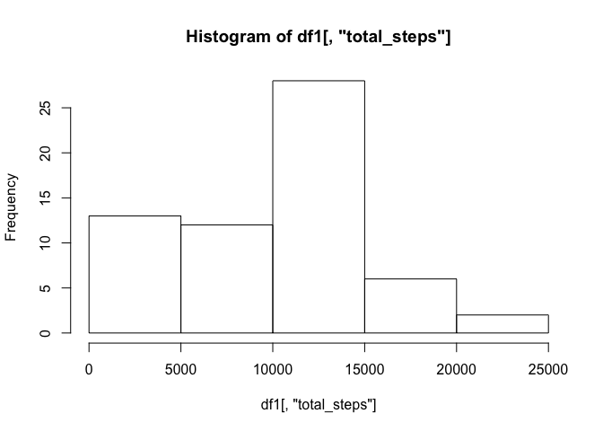

```r
library(dplyr, warn.conflicts = FALSE)
df1 <- df %>% group_by(date) %>% summarize(total_steps = sum(steps, na.rm = TRUE))
hist(df1[, 'total_steps'])
```

The table below shows the mean/median total number of steps taken per day. On days `where no measurements were available, you will see the mean/median as NaN/NA.

```r
df %>% group_by(date) %>% summarize(avg_steps = mean(steps, na.rm = TRUE), median_steps = median(steps, na.rm = TRUE))
```

```
## Source: local data frame [61 x 3]
##
##          date  avg_steps median_steps
## 1  2012-10-01        NaN           NA
## 2  2012-10-02  0.4375000            0
## 3  2012-10-03 39.4166667            0
## 4  2012-10-04 42.0694444            0
## 5  2012-10-05 46.1597222            0
## 6  2012-10-06 53.5416667            0
## 7  2012-10-07 38.2465278            0
## 8  2012-10-08        NaN           NA
## 9  2012-10-09 44.4826389            0
## 10 2012-10-10 34.3750000            0
## 11 2012-10-11 35.7777778            0
## 12 2012-10-12 60.3541667            0
```

[output cut: 49 more lines]

## What is the average daily activity pattern?

The following shows a time-series plot, with each 5-minute interval on the x-axis, and the average number of steps in that interval across all days on the y-axis.

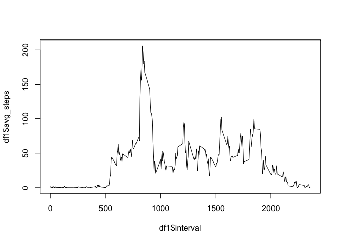

```r
df1 <- df %>% group_by(interval) %>% summarize(avg_steps = mean(steps, na.rm = TRUE))
plot(df1$interval, df1$avg_steps, type = 'l')
```

```r
interval <- df1[df1$avg_steps == max(df1$avg_steps), ]$interval
```

The 5-minute interval with the highest average is 835.

## Imputing missing values

The number of missing values for the steps parameter is 2304.

```r
sum(is.na(df$steps))
```

```
## [1] 2304
```

We will fill in each missing value with the corresponding mean for the 5-minute interval. With this strategy, here’s the new data set.

```r
df2 <- df
df1 <- df %>% group_by(interval) %>% summarize(avg_steps = mean(steps, na.rm = TRUE))
indices <- which(is.na(df2$steps))
for(i in indices) {
  df2[i, 'steps'] <- df1[df1$interval == df2[i, 'interval'], 'avg_steps']
}
```

Here’s the mean and median with the new imputed missing values. Only the days with missing values are now impacted; all the NaNs and NAs are eliminated.

```r
df2 %>% group_by(date) %>% summarize(avg_steps = mean(steps, na.rm = TRUE), median_steps = median(steps, na.rm = TRUE))
```

```
## Source: local data frame [61 x 3]
##
##          date  avg_steps median_steps
## 1  2012-10-01 37.3825996     34.11321
## 2  2012-10-02  0.4375000      0.00000
## 3  2012-10-03 39.4166667      0.00000
## 4  2012-10-04 42.0694444      0.00000
## 5  2012-10-05 46.1597222      0.00000
## 6  2012-10-06 53.5416667      0.00000
## 7  2012-10-07 38.2465278      0.00000
## 8  2012-10-08 37.3825996     34.11321
## 9  2012-10-09 44.4826389      0.00000
## 10 2012-10-10 34.3750000      0.00000
## 11 2012-10-11 35.7777778      0.00000
## 12 2012-10-12 60.3541667      0.00000
```

[output cut: 49 more lines]

## Are there differences in activity patterns between weekdays and weekends?

Let’s add a new factor variable which identifies whether the day is a weekday or a weekend.

```r
df2$weekday <- factor(ifelse(weekdays(as.Date(df2$date)) %in% c("Monday", "Tuesday", "Wednesday", "Thursday", "Friday"), "Weekday", "Weekend"))
```

Here’s a histogram of the total number of steps taken each day after the missing values are imputed.

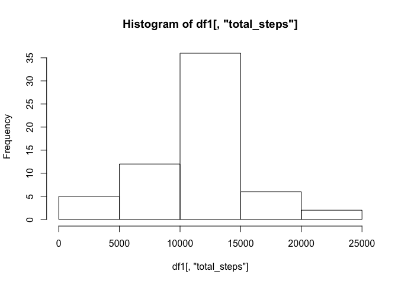

```r
df1 <- df2 %>% group_by(date) %>% summarize(total_steps = sum(steps, na.rm = TRUE))
hist(df1[, 'total_steps'])
```

Here’s a panel plot showing time series with the 5-minute intervals on the x-axis, and the average number of steps on the y-axis.

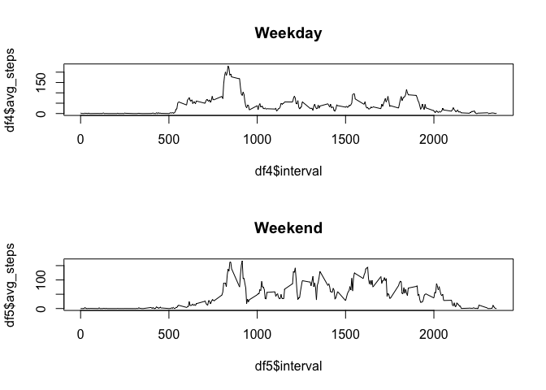

```r
df3 <- df2 %>% group_by(interval, weekday) %>% summarize(avg_steps = mean(steps, na.rm = TRUE))
df4 <- df3[df3$weekday == "Weekday", ]
df5 <- df3[df3$weekday == "Weekend", ]

library(lattice)
layout(c(1, 2), 2, 1)
plot(df4$interval, df4$avg_steps, type = "l", main = "Weekday")
plot(df5$interval, df5$avg_steps, type = "l", main = "Weekend")
```